# Variable Selection and Regression (part 3)

Ryan Miller

## The Least Squares Estimate

- For **linear regression**, $f(\mathbf{X}) = \mathbf{X} \mathbf{\beta}$ and $\epsilon_i \sim N(0,\sigma^2)$
  - This model is fit (trained) by finding estimates $\hat{\mathbf{\beta}}$
  - A strength of regression is that an analytic expression defines the optimal estimates: $\hat{\mathbf{\beta}} = (\mathbf{X}^T\mathbf{X})^{-1}\mathbf{X}^T y$

## Principle Components Regression

- Recall that principle component analysis begins by decomposing $C = \tfrac{1}{n - 1} \mathbf{X}^T\mathbf{X}$ into $\mathbf{V}\mathbf{L}\mathbf{V}^T$
  - This decomposition constructs $\mathbf{X}\mathbf{V}$ as a new data matrix containing the principle components
  - Principle Component Regression (PCR) regresses $y$ on this new matrix of principle components
  - The idea behind the approach is quite general and can used as a *pre-processing* step for *any* supervised learning approach

## Partial Least Squares

- The top $k$ components in PCR are constructed to retain the *maximum amount of variation* that exists in $\mathbf{X}$
  - But nothing requires that *any* of these components will be associated with $y$
  - In fact, they might even be less predictive of $y$ than the original variables
- Recall the least squares estimate: $\hat{\mathbf{\beta}} = (\mathbf{X}^T\mathbf{X})^{-1}\mathbf{X}^T y$
- Partial Least Squares (PLS) addresses downsides of PCR by decomposing $\mathbf{X}^T y$ (rather than decomposing $\mathbf{X}^T X$)
  - This is slightly more complicated, as it leads to loadings for both $X$ and $y$, but in the end we can plug the new representations into the least squares estimate

## PCR vs. PLS

- For the pollution data:

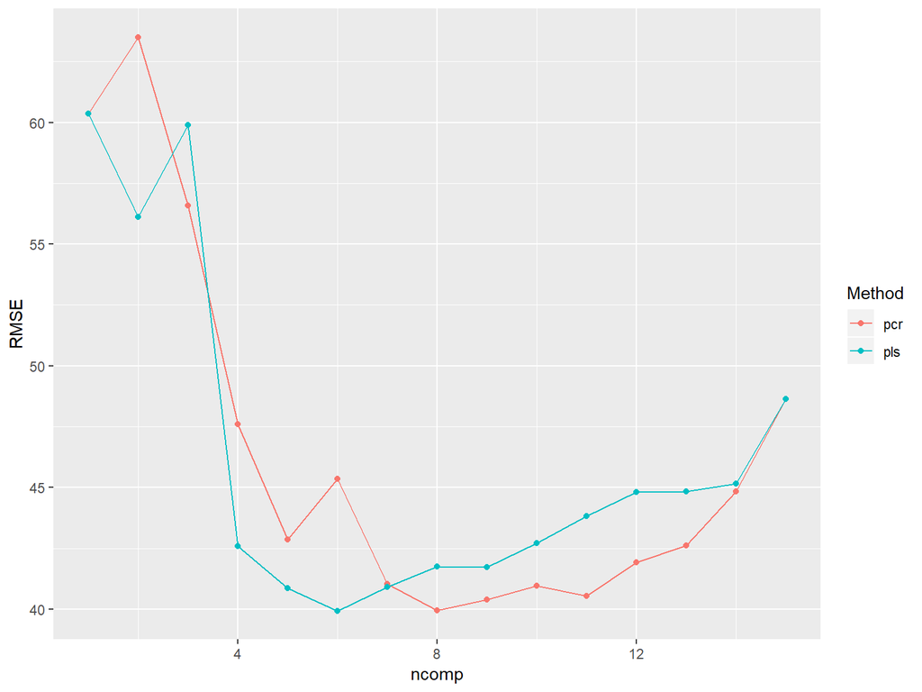

```r
pol <- readRDS(url("https://s3.amazonaws.com/pbreheny-data-sets/pollution.rds"))
df <- data.frame(y = pol$y, pol$X)

library(caret)
fit.control <- trainControl(method = "repeatedcv", number = 5, repeats = 10)

set.seed(135)
pcr.fit <- train(y ~ ., data = df, method = "pcr", trControl = fit.control, tuneGrid = data.frame(ncomp = 1:15))

set.seed(135)
pls.fit <- train(y ~ ., data = df, method = "pls", trControl = fit.control, tuneGrid = data.frame(ncomp = 1:15))

res_pcr <- data.frame(Method = "pcr", ncomp = pcr.fit$results$ncomp, RMSE = pcr.fit$results$RMSE)
res_pls <- data.frame(Method = "pls", ncomp = pls.fit$results$ncomp, RMSE = pls.fit$results$RMSE)
res <- rbind(res_pcr, res_pls)

ggplot(res, aes(x = ncomp, y = RMSE, color = Method)) + geom_line() + geom_point()
```

## Penalized Regression

- Both PCR and PLS rely on estimating the regression coefficients via least squares, they just modify the input data
- We could estimate $\mathbf{\beta}$ differently…
- The least squares estimate, $\hat{\mathbf{\beta}}$, is the minimizer of $\sum_i (y_i - \mathbf{x}_i^T \hat{\mathbf{\beta}})^2$
- The LASSO estimate, $\tilde{\mathbf{\beta}}$, is the minimizer of $\sum_i (y_i - \mathbf{x}_i^T \tilde{\mathbf{\beta}})^2 + \sum_j \lambda|\tilde{\mathbf{\beta}}_j|$
  - The quantity $\sum_j |\tilde{\beta}_j|$ is called the L1 norm, it is a penalty on the size of the regression coefficients that encourages smaller values
  - The penalty parameter, $\lambda$, controls the amount of *shrinkage* on the regression estimates

## Penalized Regression

- The penalty parameter, $\lambda$, needs to be chosen by the analyst
  - If $\lambda = 0$, the LASSO estimate is the least squares estimate
  - If $\lambda = \infty$, the LASSO estimate is $\tilde{\beta}_j = 0$ for all variables
  - In between an entire path of different sets of estimates are possible:

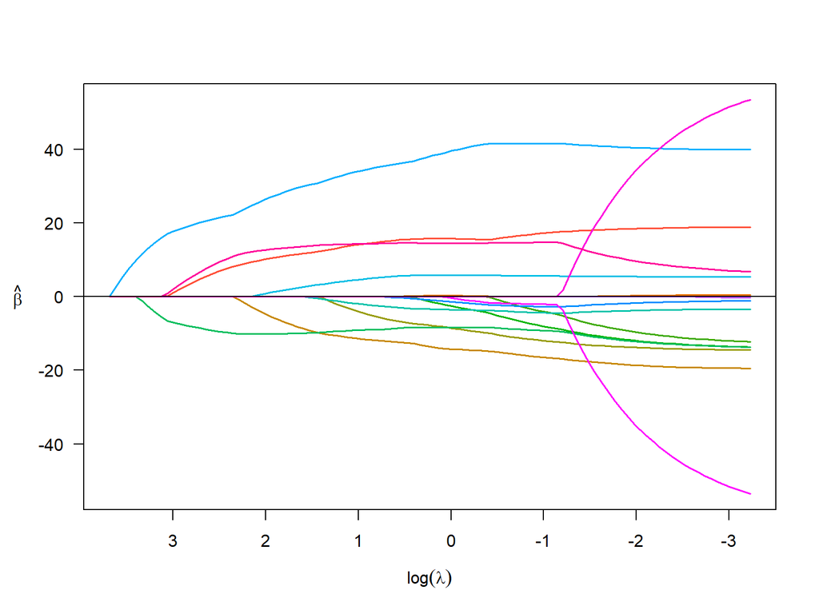

```r
library(ncvreg)
cv.lasso <- cv.ncvreg(y = df$y, X = scale(df[,-1]), penalty = "lasso")
plot(cv.lasso$fit, log.l = TRUE)
```

## Sparsity

- An amazing property of LASSO regression is that the method naturally performs variable selection
  - For example, if $log(\lambda) = 3$, only 4 of 15 variables are *active* in the model with non-zero regression coefficients
  - Thus, the LASSO solution is *sparse*, meaning only some of its components are non-zero

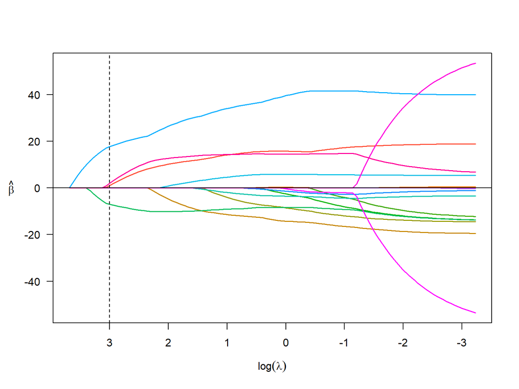

```r
plot(cv.lasso$fit, log.l = TRUE)
abline(v = 3, lty = 2)
```

## LASSO versus PCR and PLS

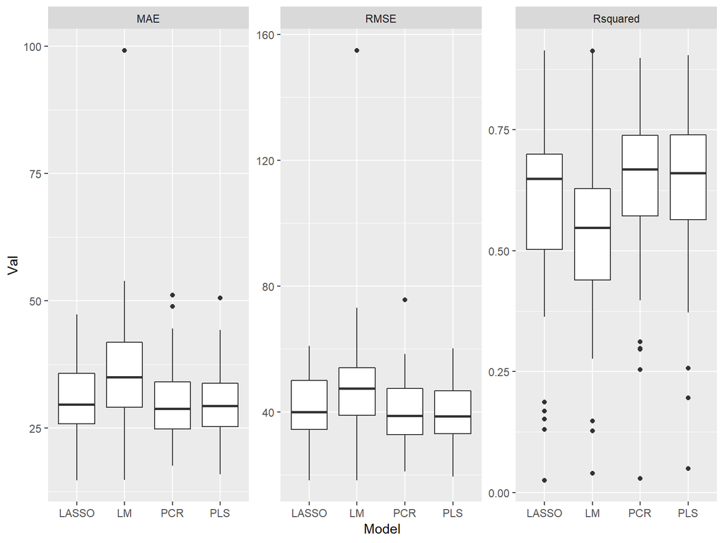

```r
## Lasso regression uses alpha = 1
set.seed(135)
lasso.fit <- train(y ~ ., data = df, method = "glmnet", trControl = fit.control,tuneGrid = data.frame(alpha = 1, lambda = seq(10,1,by = -0.25)))

## For comparison, ordinary linear regression
set.seed(135)
lm.fit <- train(y ~ ., data = df, method = "lm", trControl = fit.control )


resamps <- resamples(list(PCR = pcr.fit, PLS = pls.fit, LASSO = lasso.fit, LM = lm.fit))

resamps2 <- gather(resamps$values, key = "Var", value = "Val", 2:ncol(resamps$values))
resamps2 <- separate(resamps2, col = "Var", into = c("Model", "Metric"), sep = "~")

ggplot(resamps2, aes(x = Model, y = Val)) + geom_boxplot() + facet_wrap(~ Metric, scales = "free")
```

## LASSO versus PCR and PLS

- A major benefit of the LASSO is interpretation, since regression coefficients are estimated for the original variables, and sparsity leads to only a subset of variables making non-zero contributions:

```r
## coef returns the regression coefficients for the model with s = lambda value
coef(lasso.fit$finalModel, s = lasso.fit$bestTune$lambda)
```

```
## 16 x 1 sparse Matrix of class "dgCMatrix"
##                         1
## (Intercept)  1.066369e+03
## Precip       1.407692e+00
## Humidity     .
## JanTemp     -1.115255e+00
## JulyTemp    -8.276459e-01
## Over65       .
## House        .
## Educ        -1.082480e+01
## Sound       -3.669728e-01
## Density      3.144566e-03
## NonWhite     3.805783e+00
## WhiteCol     .
## Poor         .
## HC           .
## NOX          .
## SO2          2.256802e-01
```

## Conclusions

- PCR and PLS are popular approaches that rely on dimension reduction via deriving new features
- Penalized regression, namely the LASSO, is a popular approach that automatically selects important predictors
  - In general, LASSO offers good prediction has the advantage of allowing straightforward interpretations for each variable’s influence on the model’s predictions